# Biostat 212a Homework 2

Due Feb 8, 2026 @ 11:59PM

Author

Published

February 5, 2026

## 1 ISL Exercise 4.8.1 (10pts)

Logistic regression model(4.2)
$$p(X) = \frac{e^{\beta_0 + \beta_1 X}}{1 + e^{\beta_0 + \beta_1 X}}$$
Define the linear predictor:
$$\eta = \beta_0 + \beta_1 X$$
So the model can also be written as:
$$p(X) = \frac{e^{\eta}}{1 + e^{\eta}}$$
Compute 1−P(X):
$$1 - p(X) = \frac{1}{1 + e^{\eta}}$$
Now take the ratio:
$$\frac{p(X)}{1 - p(X)} = e^{\eta}$$
Substituting back for η gives:
$$\frac{p(X)}{1 - p(X)} = e^{\beta_0 + \beta_1 X}$$
Which is exactly (4.3)

## 2 ISL Exercise 4.8.6 (10pts)

### 2.1 (a) Estimate the Probability

The logistic function:
$$P(Y=1) =\frac{e^{\beta_0 + \beta_1X_1 + \beta_2X_2}}{1 + e^{\beta_0 + \beta_1X_1 + \beta_2X_2}}$$
1. **Calculate the linear predictor (**$z$):
$$z = -6 + 0.05(40) + 1(3.5)$$
$$z = -6 + 2 + 3.5 = -0.5$$
2. **Calculate the probability:**
$$P(Y=1) = \frac{e^{-0.5}}{1 + e^{-0.5}} \approx \frac{0.6065}{1.6065} \approx 0.3775$$
The estimated probability is **37.75%.**

### 2.2 (b) Required Study Hours

For a probability of 50% ($P=0.5$), the log-odds must equal 0. Therefore, we set the linear equation to zero:
$$0 = \hat\beta_0 + \hat\beta_1X_1 + \hat\beta_2X_2$$

1. **Plug in known values:**
   $$0 = -6 + 0.05(X_1) + 1(3.5)$$
   $$0 = -2.5 + 0.05(X_1)$$
2. **Solve for** $X_1$:
   $$2.5 = 0.05(X_1)$$
   $$X_1 = \frac{2.5}{0.05} = 50$$
   The student would need to study for **50 hours**.

## 3 ISL Exercise 4.8.9 (10pts)

### 3.1 (a)

The relationship between probability ($p$) and odds ($O$) is defined by the formula:
$$p = \frac{O}{1 + O}$$

1. **Plug in the given odds:**
   $$p = \frac{0.37}{1 + 0.37}$$
2. **Calculate the result:**
   $$p = \frac{0.37}{1.37} \approx 0.2701$$
   Approximately **27.01%** of people will default.

### 3.2 (b) we use the formula: $$O = \frac{p}{1 - p}$$

3. **Plug in the given probability (**$p = 0.16$):
   $$O = \frac{0.16}{1 - 0.16}$$
4. **Calculate the result:**
   $$O = \frac{0.16}{0.84} \approx 0.1905$$
   The odds of defaulting are approximately **0.1905**.

## 4 ISL Exercise 4.8.13 (a)-(i) (50pts)

```r
library(ISLR2)
library(dplyr)
library(ggplot2)
```

### 4.1 (a)

```r
glimpse(Weekly)
```

```
Rows: 1,089
Columns: 9
$ Year      <dbl> 1990, 1990, 1990, 1990, 1990, 1990, 1990, 1990, 1990, 1990, …
$ Lag1      <dbl> 0.816, -0.270, -2.576, 3.514, 0.712, 1.178, -1.372, 0.807, 0…
$ Lag2      <dbl> 1.572, 0.816, -0.270, -2.576, 3.514, 0.712, 1.178, -1.372, 0…
$ Lag3      <dbl> -3.936, 1.572, 0.816, -0.270, -2.576, 3.514, 0.712, 1.178, -…
$ Lag4      <dbl> -0.229, -3.936, 1.572, 0.816, -0.270, -2.576, 3.514, 0.712, …
$ Lag5      <dbl> -3.484, -0.229, -3.936, 1.572, 0.816, -0.270, -2.576, 3.514,…
$ Volume    <dbl> 0.1549760, 0.1485740, 0.1598375, 0.1616300, 0.1537280, 0.154…
$ Today     <dbl> -0.270, -2.576, 3.514, 0.712, 1.178, -1.372, 0.807, 0.041, 1…
$ Direction <fct> Down, Down, Up, Up, Up, Down, Up, Up, Up, Down, Down, Up, Up…
```

```r
summary(Weekly)
```

```
      Year           Lag1               Lag2               Lag3
 Min.   :1990   Min.   :-18.1950   Min.   :-18.1950   Min.   :-18.1950
 1st Qu.:1995   1st Qu.: -1.1540   1st Qu.: -1.1540   1st Qu.: -1.1580
 Median :2000   Median :  0.2410   Median :  0.2410   Median :  0.2410
 Mean   :2000   Mean   :  0.1506   Mean   :  0.1511   Mean   :  0.1472
 3rd Qu.:2005   3rd Qu.:  1.4050   3rd Qu.:  1.4090   3rd Qu.:  1.4090
 Max.   :2010   Max.   : 12.0260   Max.   : 12.0260   Max.   : 12.0260
      Lag4               Lag5              Volume            Today
 Min.   :-18.1950   Min.   :-18.1950   Min.   :0.08747   Min.   :-18.1950
 1st Qu.: -1.1580   1st Qu.: -1.1660   1st Qu.:0.33202   1st Qu.: -1.1540
 Median :  0.2380   Median :  0.2340   Median :1.00268   Median :  0.2410
 Mean   :  0.1458   Mean   :  0.1399   Mean   :1.57462   Mean   :  0.1499
 3rd Qu.:  1.4090   3rd Qu.:  1.4050   3rd Qu.:2.05373   3rd Qu.:  1.4050
 Max.   : 12.0260   Max.   : 12.0260   Max.   :9.32821   Max.   : 12.0260
 Direction
 Down:484
 Up  :605
```

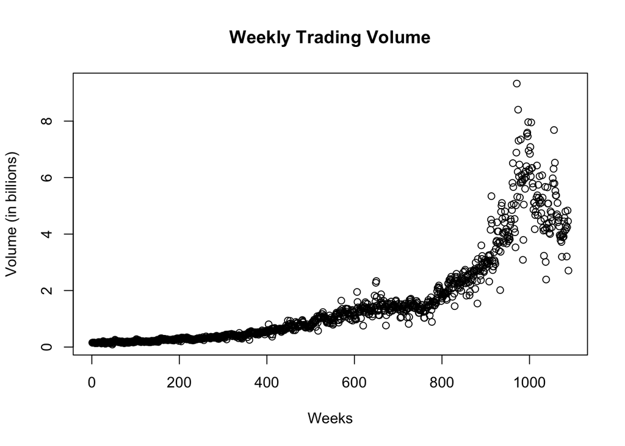

Figure 1: Trading Volume over time (1990-2010)

```r
plot(Weekly$Volume,
     main="Weekly Trading Volume",
     xlab="Weeks",
     ylab="Volume (in billions)")
```

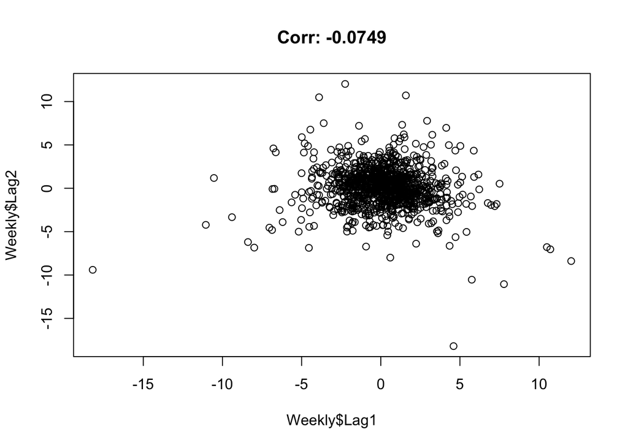

Lag 1 vs Lag 2

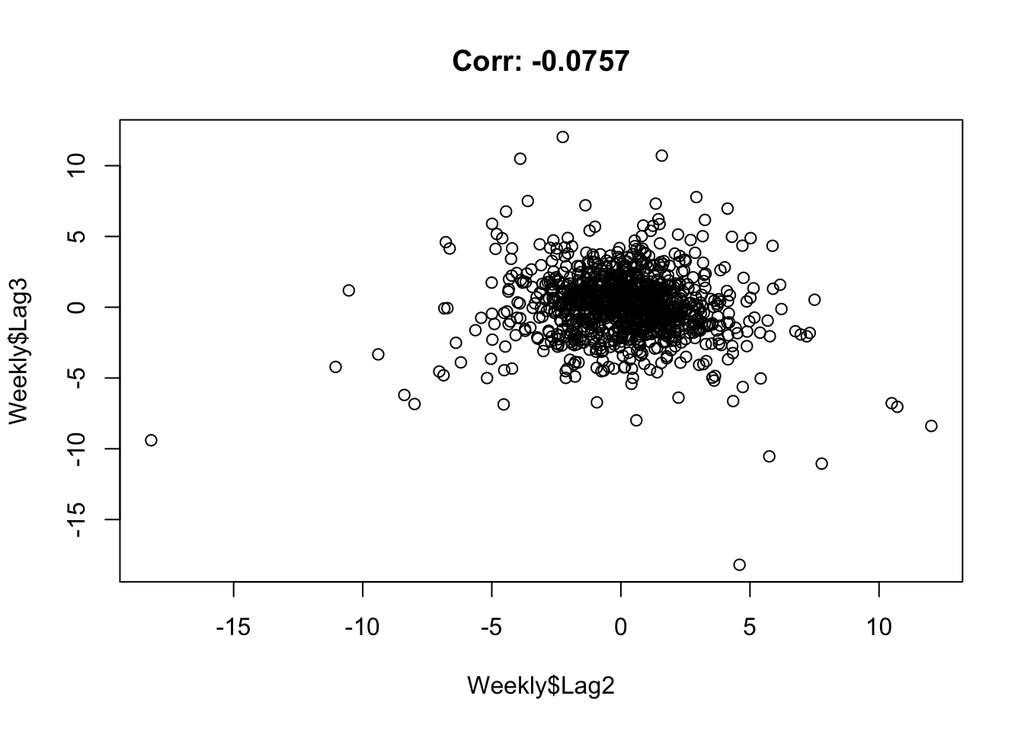

Lag 2 vs Lag 3

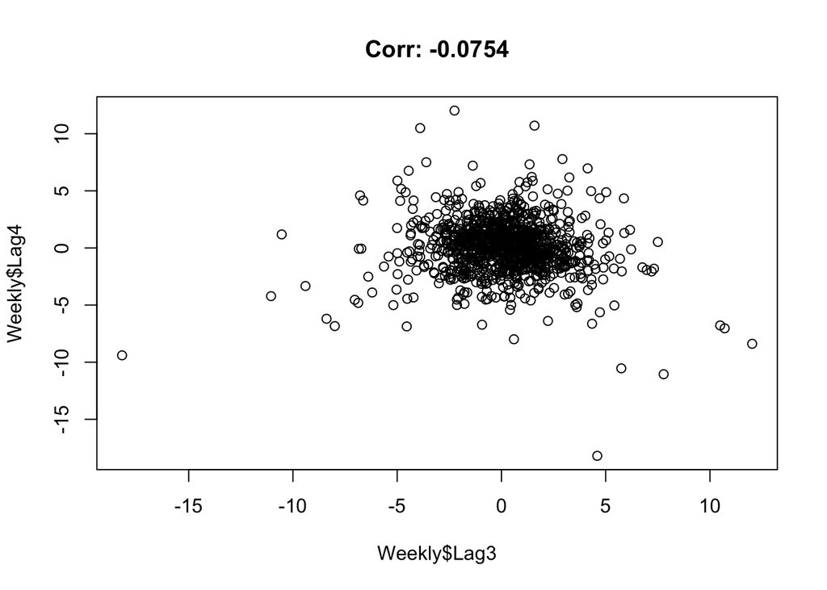

Lag 3 vs Lag 4

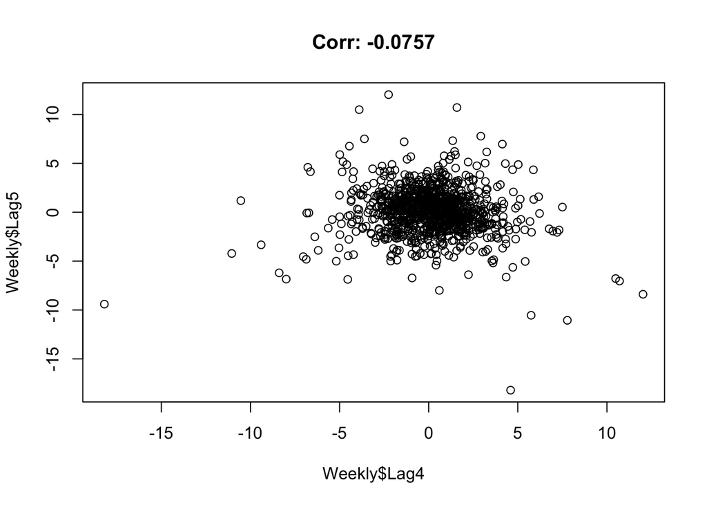

Lag 4 vs Lag 5

```r
# Correlations
cor_12 <- cor(Weekly$Lag1, Weekly$Lag2)
cor_23 <- cor(Weekly$Lag2, Weekly$Lag3)
cor_34 <- cor(Weekly$Lag3, Weekly$Lag4)
cor_45 <- cor(Weekly$Lag4, Weekly$Lag5)

plot(Weekly$Lag1, Weekly$Lag2, main=paste("Corr:", round(cor_12, 4)))
plot(Weekly$Lag2, Weekly$Lag3, main=paste("Corr:", round(cor_23, 4)))
plot(Weekly$Lag3, Weekly$Lag4, main=paste("Corr:", round(cor_34, 4)))
plot(Weekly$Lag4, Weekly$Lag5, main=paste("Corr:", round(cor_45, 4)))
```

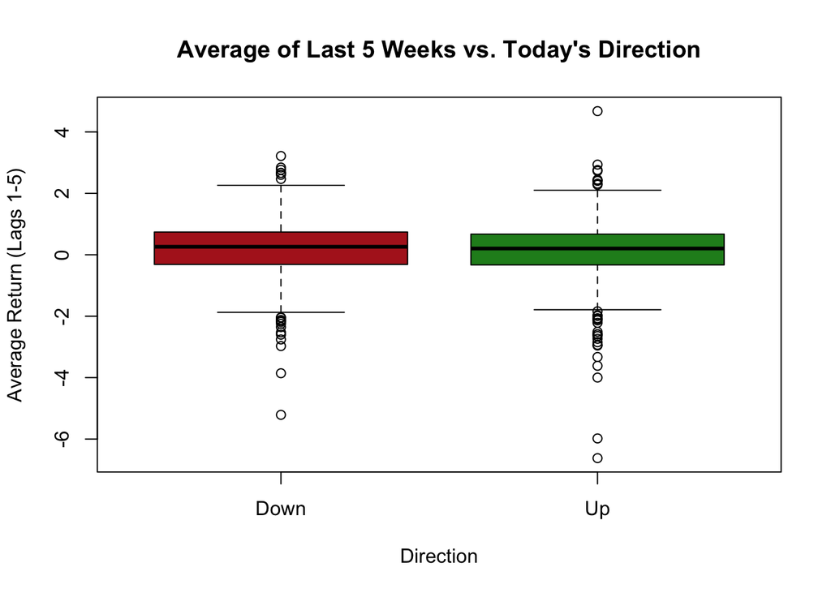

```r
# Create the average lag variable
Weekly$Lag_Avg <- rowMeans(Weekly[, c("Lag1", "Lag2", "Lag3", "Lag4", "Lag5")])

# Boxplot comparison
boxplot(Lag_Avg ~ Direction, data = Weekly,
        col = c("firebrick", "forestgreen"),
        main = "Average of Last 5 Weeks vs. Today's Direction",
        ylab = "Average Return (Lags 1-5)")
```

```r
# Mean Comparison
aggregate(Lag_Avg ~ Direction, data = Weekly, mean)
```

```
  Direction   Lag_Avg
1      Down 0.1674748
2        Up 0.1304688
```

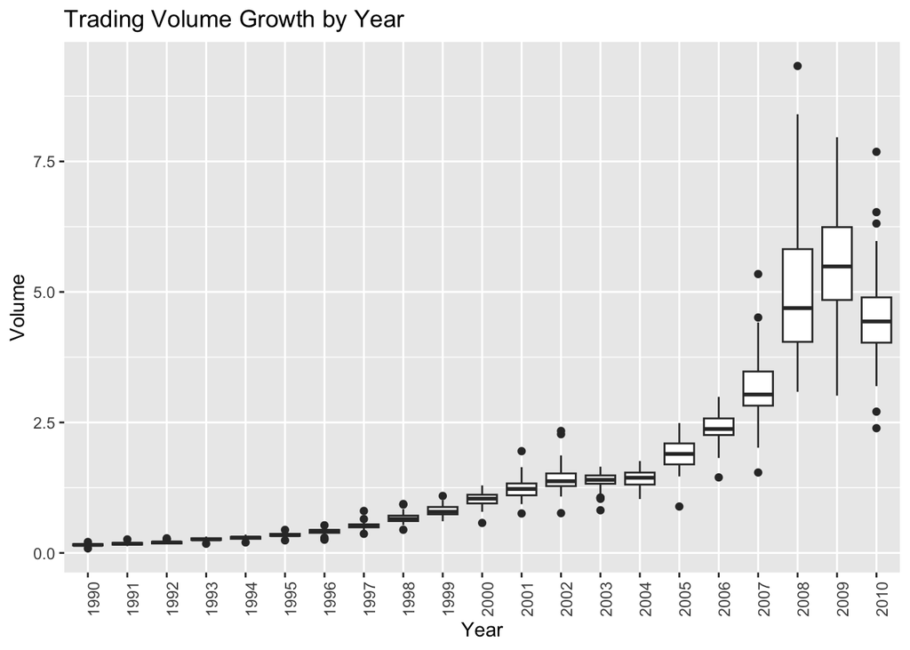

```r
# Compare Volume by Year to see the explosion in trading activity
library(ggplot2)
ggplot(Weekly, aes(x = factor(Year), y = Volume)) +
  geom_boxplot() +
  theme(axis.text.x = element_text(angle = 90)) +
  labs(title = "Trading Volume Growth by Year", x = "Year")
```

### 4.2 (b)

```r
library(gtsummary)
logit_mod<- glm(
  Direction ~ Lag1 + Lag2 + Lag3 + Lag4 + Lag5 + Volume,
  data = Weekly,
  family = binomial
)

summary(logit_mod)
```

```
Call:
glm(formula = Direction ~ Lag1 + Lag2 + Lag3 + Lag4 + Lag5 +
    Volume, family = binomial, data = Weekly)

Coefficients:
            Estimate Std. Error z value Pr(>|z|)
(Intercept)  0.26686    0.08593   3.106   0.0019 **
Lag1        -0.04127    0.02641  -1.563   0.1181
Lag2         0.05844    0.02686   2.175   0.0296 *
Lag3        -0.01606    0.02666  -0.602   0.5469
Lag4        -0.02779    0.02646  -1.050   0.2937
Lag5        -0.01447    0.02638  -0.549   0.5833
Volume      -0.02274    0.03690  -0.616   0.5377
---
Signif. codes:  0 '***' 0.001 '**' 0.01 '*' 0.05 '.' 0.1 ' ' 1

(Dispersion parameter for binomial family taken to be 1)

    Null deviance: 1496.2  on 1088  degrees of freedom
Residual deviance: 1486.4  on 1082  degrees of freedom
AIC: 1500.4

Number of Fisher Scoring iterations: 4
```

Based on the output, the only predictor that appears to be statistically significant is **`Lag2`**. Its p-value is approximately **0.0296**, which is below the 0.05 threshold.

```r
#  Get predicted probabilities
logit_probs <- predict(logit_mod, type = "response")

#  Create a vector of "Down" predictions
logit_pred <- rep("Down", length(logit_probs))

#  Change to "Up" where probability > 0.5
logit_pred[logit_probs > 0.5] <- "Up"

# Generate the confusion matrix
table(Predicted = logit_pred, Actual = Weekly$Direction)
```

```
         Actual
Predicted Down  Up
     Down   54  48
     Up    430 557
```

```r
# Calculate overall fraction of correct predictions (Accuracy)
mean(logit_pred == Weekly$Direction)
```

```
[1] 0.5610652
```

**1. Overall Accuracy:** The model correctly predicts the market direction approximately **56.1%** of the time.

**2. The Mistakes:** The confusion matrix reveals a significant bias in the model’s performance:

- **True Positives (Up predicted as Up):** The model is very good at identifying “Up” weeks. It correctly predicted **557** “Up” weeks out of 605 actual “Up” weeks (a sensitivity of about $92\%$).
- **False Positives (Down predicted as Up):** This is the model’s main weakness. It predicted “Up” for **430** weeks that actually went “Down”.
- **True Negatives (Down predicted as Down):** The model only correctly identified **54** “Down” weeks out of 484 actual “Down” weeks (a specificity of only about $11\%$).

**Conclusion:** The logistic regression model is **over-predicting the “Up” direction**. Because the market went “Up” more often than “Down” during this 21-year period ($605/1089 \approx 55.6\%$), a “naive” model that simply predicted “Up” every single week would have an accuracy of $55.6\%$. Our model’s accuracy ($56.1\%$) is barely better than that naive baseline, suggesting it has very little actual predictive power.

### 4.3 (d)

#### 4.3.1 1. Split the Data

```r
# Create training index
train <- (Weekly$Year < 2009)

# Create the test set
Weekly.test <- Weekly[!train, ]
Direction.test <- Weekly$Direction[!train]
```

#### 4.3.2 2. Fit the Model and Predict

```r
glm_fit_train <- glm(
  Direction ~ Lag2,
  data = Weekly,
  family = binomial,
  subset = train
)

# Predict probabilities for the test data (2009-2010)
glm_probs_test <- predict(glm_fit_train, Weekly.test, type = "response")

# Convert probabilities to class labels ("Down" or "Up")
glm_pred_test <- rep("Down", length(glm_probs_test))
glm_pred_test[glm_probs_test > 0.5] <- "Up"
```

#### 4.3.3 3. Confusion Matrix and Accuracy

```r
table(Predicted = glm_pred_test, Actual = Direction.test)
```

```
         Actual
Predicted Down Up
     Down    9  5
     Up     34 56
```

```r
mean(glm_pred_test == Direction.test)
```

```
[1] 0.625
```

### 4.4 (e)

```r
library(MASS)

# Fit LDA model on the training data
lda_mod <- lda(
  Direction ~ Lag2,
  data = Weekly,
  subset = train)

lda_mod
```

```
Call:
lda(Direction ~ Lag2, data = Weekly, subset = train)

Prior probabilities of groups:
     Down        Up
0.4477157 0.5522843

Group means:
            Lag2
Down -0.03568254
Up    0.26036581

Coefficients of linear discriminants:
           LD1
Lag2 0.4414162
```

```r
# Make predictions on the test set
lda_pred <- predict(lda_mod, Weekly.test)

# The predict() function for LDA returns a list;
# 'class' contains the Down/Up labels.
lda_class <- lda_pred$class

# Confusion Matrix
table(Predicted = lda_class, Actual = Direction.test)
```

```
         Actual
Predicted Down Up
     Down    9  5
     Up     34 56
```

```r
# Overall Accuracy
mean(lda_class == Direction.test)
```

```
[1] 0.625
```

### 4.5 (f)

```r
# Fit QDA model on the training data
qda_fit <- qda(Direction ~ Lag2, data = Weekly, subset = train)

qda_fit
```

```
Call:
qda(Direction ~ Lag2, data = Weekly, subset = train)

Prior probabilities of groups:
     Down        Up
0.4477157 0.5522843

Group means:
            Lag2
Down -0.03568254
Up    0.26036581
```

```r
# Make predictions on the test set
qda_pred <- predict(qda_fit, Weekly.test)
qda_class <- qda_pred$class

# Confusion Matrix
table(Predicted = qda_class, Actual = Direction.test)
```

```
         Actual
Predicted Down Up
     Down    0  0
     Up     43 61
```

```r
# Overall Accuracy
mean(qda_class == Direction.test)
```

```
[1] 0.5865385
```

### 4.6 (g)

```r
library(class)

train.X <- as.matrix(Weekly$Lag2[train])
test.X <- as.matrix(Weekly$Lag2[!train])

# Create the vector for training labels
train.Direction <- Weekly$Direction[train]
```

```r
set.seed(1)
knn.pred <- knn(train.X, test.X, train.Direction, k = 1)

# Confusion Matrix
table(Predicted = knn.pred, Actual = Direction.test)
```

```
         Actual
Predicted Down Up
     Down   21 30
     Up     22 31
```

```r
# Overall Accuracy
mean(knn.pred == Direction.test)
```

```
[1] 0.5
```

### 4.7 (h)

```r
library(e1071)

# Fit the Naive Bayes model
nb_fit <- naiveBayes(Direction ~ Lag2, data = Weekly, subset = train)

nb_fit
```

```
Naive Bayes Classifier for Discrete Predictors

Call:
naiveBayes.default(x = X, y = Y, laplace = laplace)

A-priori probabilities:
Y
     Down        Up
0.4477157 0.5522843

Conditional probabilities:
      Lag2
Y             [,1]     [,2]
  Down -0.03568254 2.199504
  Up    0.26036581 2.317485
```

```r
# Make predictions
nb_class <- predict(nb_fit, Weekly.test)

# Confusion Matrix
table(Predicted = nb_class, Actual = Direction.test)
```

```
         Actual
Predicted Down Up
     Down    0  0
     Up     43 61
```

```r
# Overall Accuracy
mean(nb_class == Direction.test)
```

```
[1] 0.5865385
```

### 4.8 (i)

Summary of Model Performance  
Logistic Regression: 62.5%  
LDA: 62.5%  
Naive Bayes: 58.7%  
KNN (K=1): 50.0%  
Based on these results, **Logistic Regression** and **LDA** provided the best results for this data.

## 5 Bonus question: ISL Exercise 4.8.13 Part (j) (30pts)

### 5.1 1. The “Momentum” Logistic Model (Lag1 + Lag2)

Sometimes the immediate past week (`Lag1`) and the significant week (`Lag2`) work together to show a trend.

```r
# Logistic Regression with Lag1 and Lag2
glm_mom <- glm(Direction ~ Lag1 + Lag2,
               data = Weekly, family = binomial, subset = train)

glm_probs_mom <- predict(glm_mom, Weekly.test, type = "response")
glm_pred_mom <- rep("Down", length(glm_probs_mom))
glm_pred_mom[glm_probs_mom > 0.5] <- "Up"

mean(glm_pred_mom == Direction.test)
```

```
[1] 0.5769231
```

### 5.2 2. Logistic Regression with Interaction (Lag2 * Volume)

We test if the effect of `Lag2` depends on the trading `Volume`.

```r
# Logistic Regression with Interaction
glm_exp <- glm(Direction ~ Lag2:Volume + Lag2,
               data = Weekly, family = binomial, subset = train)

glm_probs_exp <- predict(glm_exp, Weekly.test, type = "response")
glm_pred_exp <- rep("Down", length(glm_probs_exp))
glm_pred_exp[glm_probs_exp > 0.5] <- "Up"

# Accuracy
mean(glm_pred_exp == Direction.test)
```

```
[1] 0.625
```

### 5.3 3. The “Volatility” LDA Model (Interaction & Squares)

We test if the interaction between Volume and price movement, or the squared return (volatility), helps.

```r
# LDA with Volume interaction and squared Lag2
lda_vol <- lda(Direction ~ Lag2 * Volume + I(Lag2^2),
               data = Weekly, subset = train)

lda_pred_vol <- predict(lda_vol, Weekly.test)$class
table(Predicted = lda_pred_vol, Actual = Direction.test)
```

```
         Actual
Predicted Down Up
     Down   24 32
     Up     19 29
```

```r
mean(lda_pred_vol == Direction.test)
```

```
[1] 0.5096154
```

### 5.4 4. Optimized KNN (Multi-variable)

We use all 5 Lags but increase $K$ significantly to act as a “smoother.”

```r
# Use all Lags for KNN
train.X_all <- as.matrix(Weekly[train, c("Lag1", "Lag2", "Lag3", "Lag4", "Lag5")])
test.X_all <- as.matrix(Weekly[!train, c("Lag1", "Lag2", "Lag3", "Lag4", "Lag5")])

set.seed(1)
# Try K = 50 for a stable multi-variable boundary
knn_all_pred <- knn(train.X_all, test.X_all, train.Direction, k = 50)
mean(knn_all_pred == Direction.test)
```

```
[1] 0.5096154
```

### 5.5 5. KNN with Optimized K (K = 10 and K = 100)

A larger $K$ provides a smoother decision boundary, which usually helps with noisy financial data.

```r
set.seed(1)
# Testing K = 10
knn_10_pred <- knn(train.X, test.X, train.Direction, k = 10)
acc_10 <- mean(knn_10_pred == Direction.test)

# Testing K = 100
knn_100_pred <- knn(train.X, test.X, train.Direction, k = 100)
acc_100 <- mean(knn_100_pred == Direction.test)

cat("Accuracy K=10:", acc_10, "\nAccuracy K=100:", acc_100)
```

```
Accuracy K=10: 0.5480769
Accuracy K=100: 0.5576923
```

After I experimented with multiple predictors (Lag1–Lag5, Volume, interactions, and squared terms) across all methods, the simplest model (Logistic/LDA with only Lag2) remained the most robust.

## 6 Bonus question: ISL Exercise 4.8.4 (30pts)